# [post](https://gomesfellipe.github.io/)

### 3. Distributions of numerical variables

Graphical representation of all numeric features

- Quantile-quantile plot(Univariate)

```r
ExpOutQQ(data,nlim=4,fname=NULL,Page=c(2,2),sample=sn)
```

```
## $`0`
```

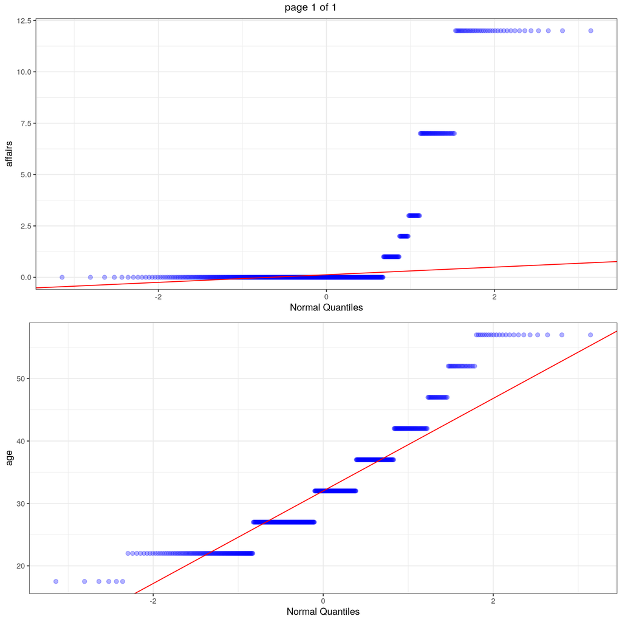

- Density plot (Univariate)

```
## $`0`
```

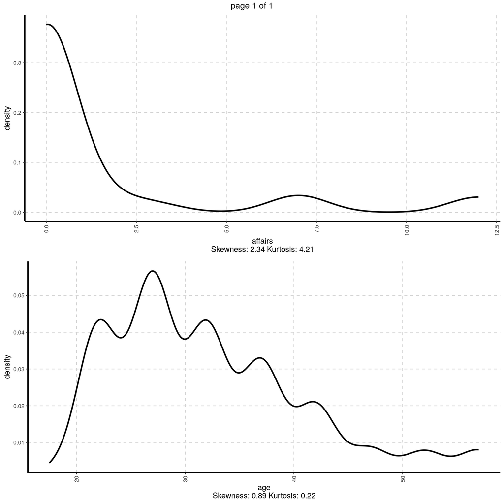

```r
ExpNumViz(data,target=NULL,type=1,nlim=NULL,fname=NULL,col=NULL,Page=c(2,2),theme=theme,sample=sn)
```

- Scatter plot (Bivariate)

```
## $`0`
```

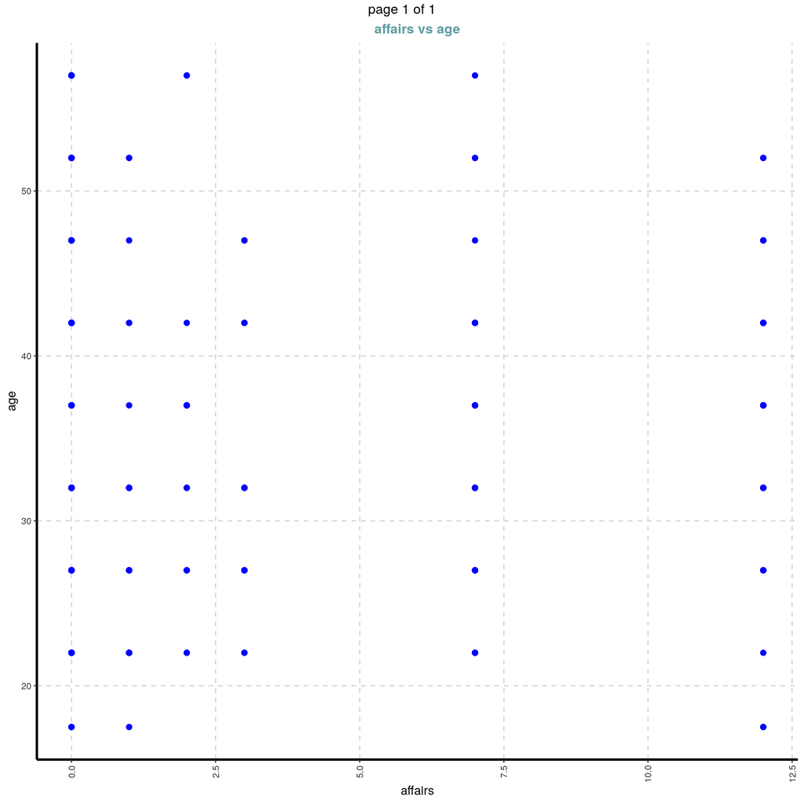

```r
ExpNumViz(data,Page=c(2,1),sample=sn,theme=theme,scatter=TRUE)
```

### 4. Summary of categorical variables

Summary of categorical variables

- frequency for all categorical independent variables

```r
ExpCTable(data,Target=NULL,margin=1,clim=10,nlim=NULL,round=2,bin=NULL,per=T)
```

| Variable | Valid | Frequency | Percent | CumPercent |
| --- | --- | --- | --- | --- |
| gender | female | 315 | 52.41 | 52.41 |
| gender | male | 286 | 47.59 | 100.00 |
| gender | TOTAL | 601 | NA | NA |
| yearsmarried | 9-11 anos | 70 | 11.65 | 11.65 |
| yearsmarried | 1-2 | 88 | 14.64 | 26.29 |
| yearsmarried | 12 ou mais anos | 204 | 33.94 | 60.23 |
| yearsmarried | 3 meses ou menos, casado | 11 | 1.83 | 62.06 |
| yearsmarried | 3-5 anos | 105 | 17.47 | 79.53 |
| yearsmarried | 4-6 meses | 10 | 1.66 | 81.19 |
| yearsmarried | 6 meses-1 ano | 31 | 5.16 | 86.35 |

[output cut: 32 more lines]

> *`NA` is Not Applicable*